# File 2_Exploratory Data Analysis Portfolio

```python
import pandas
import pandas as pd
import numpy as np

from scipy import stats
from sklearn.model_selection import train_test_split
from sklearn.linear_model import LinearRegression
from sklearn.metrics import mean_squared_error, r2_score
from sklearn.tree import DecisionTreeRegressor
from sklearn.neighbors import KNeighborsRegressor
from sklearn.model_selection import GridSearchCV
from sklearn import tree
from sklearn.model_selection import cross_val_score
from sklearn.metrics import accuracy_score
from sklearn.neighbors import KNeighborsClassifier
from sklearn import neighbors

import matplotlib.pyplot as plt
from pandas.plotting import register_matplotlib_converters
register_matplotlib_converters()
```

## Describe this dataset

```python
# Define the full file path
file_path = r'C:\Users\pweve\BSYS 4001\Data\merged_df_full.csv'

# Load the CSV file
merged_df = pd.read_csv(file_path)

# Display the first 10 rows
print(merged_df.head(10))
```

```
   PickupDate PickupTime  Type
0  2023-03-07   19:24:39  taxi
1  2023-03-07   19:24:39  taxi
2  2023-03-07   19:24:39  taxi
3  2023-03-07   11:11:59  taxi
4  2023-03-07   21:20:11  taxi
5  2023-03-07   21:20:11  taxi
6  2023-03-07   11:11:59  taxi
7  2023-03-07   11:11:59  taxi
8  2023-03-07   19:24:39  taxi
9  2023-03-07   20:17:24  taxi
```

```python
merged_df.describe(include= "all")
```

|  | PickupDate | PickupTime | Type |
| --- | --- | --- | --- |
| count | 30552 | 30552 | 30552 |
| unique | 23 | 23486 | 2 |
| top | 2023-02-28 | 20:21:18 | rideshare |
| freq | 2305 | 8 | 23373 |

```python
print(merged_df.shape)
print("There are ", merged_df.shape[0]," rows and ",merged_df.shape[1]," columns")
```

```
(30552, 3)
There are  30552  rows and  3  columns
```

```python
counts = merged_df['Type'].value_counts()
print(counts)
```

```
rideshare    23373
taxi          7179
Name: Type, dtype: int64
```

```python
merged_df['PickupDate'] = pd.to_datetime(merged_df['PickupDate'], errors='coerce')

min_date = merged_df['PickupDate'].min()
max_date = merged_df['PickupDate'].max()

print(f"The data spans a period of time from {min_date.date()} to {max_date.date()}.")
```

```
The data spans a period of time from 2023-02-15 to 2023-03-09.
```

This dataset contains information about taxi and rideshare pickups which is including

- pickup date
- pickup time
- type of service (either "taxi" or "rideshare")

## summarize this dataset

```python
merged_df['PickupDate'] = pd.to_datetime(merged_df['PickupDate'])

feb_rides = merged_df[merged_df['PickupDate'].dt.month == 2]
num_rides_feb = feb_rides.shape[0]

march_rides = merged_df[merged_df['PickupDate'].dt.month == 3]
num_rides_march = march_rides.shape[0]

print("Total number of rides taken in Feb 2023:", num_rides_feb)
print("Total number of rides taken in March 2023:", num_rides_march)
```

```
Total number of rides taken in Feb 2023: 27661
Total number of rides taken in March 2023: 2891
```

```python
merged_df['PickupDate'] = pd.to_datetime(merged_df['PickupDate'])


rides_per_day = merged_df.groupby('PickupDate').size()


avg_rides_per_day = rides_per_day.mean()
std_rides_per_day = rides_per_day.std()


max_rides_day = rides_per_day.idxmax()
max_rides = rides_per_day.loc[max_rides_day]

min_rides_day = rides_per_day.idxmin()
min_rides = rides_per_day.loc[min_rides_day]


print("The average number of rides per day:", avg_rides_per_day)
print("The standard deviation of rides per day:", std_rides_per_day)

print("Day with the maximum number of rides:", max_rides_day.date(), end=". ")
print("Number of rides on the maximum day:", max_rides, end="\n")
print("Day with the minimum number of rides:", min_rides_day.date(), end=". ")
print("Number of rides on the minimum day:", min_rides, end="\n")
```

```
The average number of rides per day: 1328.3478260869565
The standard deviation of rides per day: 847.7855972899823
Day with the maximum number of rides: 2023-02-28. Number of rides on the maximum day: 2305
Day with the minimum number of rides: 2023-03-04. Number of rides on the minimum day: 209
```

```python
merged_df['PickupTime'] = pd.to_datetime(merged_df['PickupTime'])

# extract hour from PickupTime and create new column
merged_df['PickupHour'] = merged_df['PickupTime'].dt.hour

taxi_hr = merged_df[merged_df['Type'] == 'taxi']
rideshare_hr = merged_df[merged_df['Type'] == 'rideshare']
taxi_rideshare_hr = merged_df[(merged_df['Type'] == 'taxi') | (merged_df['Type'] == 'rideshare')]

# count occurrences of each pickup hour
taxi_counts = taxi_hr['PickupHour'].value_counts()
rideshare_counts = rideshare_hr['PickupHour'].value_counts()
pickup_counts = taxi_rideshare_hr['PickupHour'].value_counts()

# find the most common pickup hour
most_common_taxihr = pd.to_datetime(taxi_counts.idxmax(), format='%H').strftime('%H:%M:%S')
most_common_ridesharehr = pd.to_datetime(rideshare_counts.idxmax(), format='%H').strftime('%H:%M:%S')
most_common_hour = pd.to_datetime(pickup_counts.idxmax(), format='%H').strftime('%H:%M:%S')

print("The most common pickup hour for taxis is:", most_common_taxihr)
print("The most common pickup hour for rideshares is:", most_common_ridesharehr)
print("The most common pickup hour for taxis and rideshares is:", most_common_hour)
```

```
The most common pickup hour for taxis is: 17:00:00
The most common pickup hour for rideshares is: 12:00:00
The most common pickup hour for taxis and rideshares is: 12:00:00
```

```python
# extract hour and minute from PickupTime and create new columns
merged_df['PickupHour'] = merged_df['PickupTime'].dt.hour
merged_df['PickupMinute'] = merged_df['PickupTime'].dt.minute

# create bins for every 30 minutes
bin_intervals = pd.interval_range(start=0, end=60, freq=30)
merged_df['TimeBin'] = pd.cut(merged_df['PickupMinute'], bins=bin_intervals, include_lowest=True)

# create separate dataframes for taxi and rideshare
taxi_hr = merged_df[merged_df['Type'] == 'taxi']
rideshare_hr = merged_df[merged_df['Type'] == 'rideshare']
taxi_rideshare_hr = merged_df[(merged_df['Type'] == 'taxi') | (merged_df['Type'] == 'rideshare')]

# count occurrences of each pickup hour and 30-minute interval
taxi_counts = taxi_hr.groupby(['PickupHour', 'TimeBin']).size()
rideshare_counts = rideshare_hr.groupby(['PickupHour', 'TimeBin']).size()
pickup_counts = taxi_rideshare_hr.groupby(['PickupHour', 'TimeBin']).size()

# find the most common pickup hour and 30-minute interval
most_common_taxihr = taxi_counts.idxmax()
most_common_ridesharehr = rideshare_counts.idxmax()
most_common_hour = pickup_counts.idxmax()

# get the counts for the most common pickup hour and 30-minute interval
most_common_taxihr_count = taxi_counts.max()
most_common_ridesharehr_count = rideshare_counts.max()
most_common_hour_count = pickup_counts.max()

# format the output
taxi_interval = f"{most_common_taxihr[0]:02d}:{most_common_taxihr[1].left:02d}-{most_common_taxihr[0] + most_common_taxihr[1].right // 60:02d}:{most_common_taxihr[1].right % 60:02d}"
rideshare_interval = f"{most_common_ridesharehr[0]:02d}:{most_common_ridesharehr[1].left:02d}-{most_common_ridesharehr[0] + most_common_ridesharehr[1].right // 60:02d}:{most_common_ridesharehr[1].right % 60:02d}"
combined_interval = f"{most_common_hour[0]:02d}:{most_common_hour[1].left:02d}-{most_common_hour[0] + most_common_hour[1].right // 60:02d}:{most_common_hour[1].right % 60:02d}"

print("The most common pickup hour and 30-minute interval for taxis is:", taxi_interval, "with a count of", most_common_taxihr_count)
print("The most common pickup hour and 30-minute interval for rideshares is:", rideshare_interval, "with a count of", most_common_ridesharehr_count)
print("The most common pickup hour and 30-minute interval for taxis and rideshares is:", combined_interval, "with a count of", most_common_hour_count)
```

```
The most common pickup hour and 30-minute interval for taxis is: 17:30-18:00 with a count of 298
The most common pickup hour and 30-minute interval for rideshares is: 21:30-22:00 with a count of 874
The most common pickup hour and 30-minute interval for taxis and rideshares is: 21:30-22:00 with a count of 1075
```

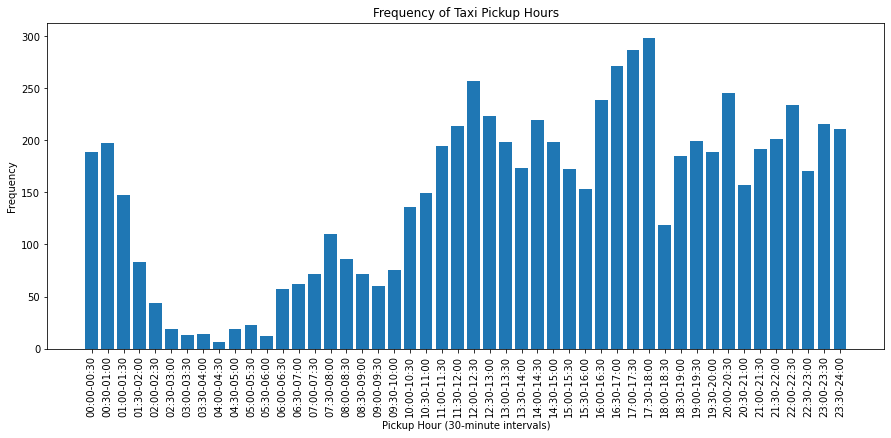

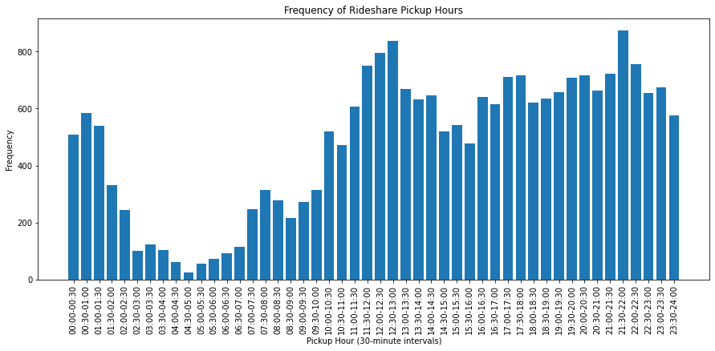

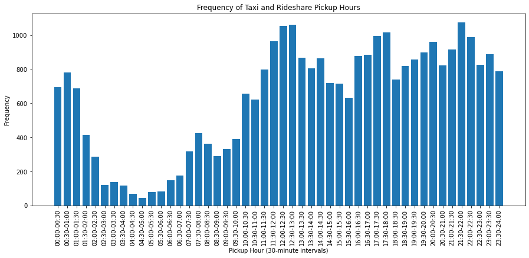

```python
def count_intervals(counts):
    interval_counts = {}
    for index, value in counts.iteritems():
        hour = index[0]
        minute_range = index[1]
        interval_start = f"{hour:02d}:{minute_range.left:02d}"
        interval_end = f"{hour + minute_range.right // 60:02d}:{minute_range.right % 60:02d}"
        interval = f"{interval_start}-{interval_end}"
        interval_counts[interval] = interval_counts.get(interval, 0) + value
    return interval_counts

taxi_interval_counts = count_intervals(taxi_counts)
rideshare_interval_counts = count_intervals(rideshare_counts)
pickup_interval_counts = count_intervals(pickup_counts)


fig, ax = plt.subplots(figsize=(15, 6))
# create a bar chart for taxi pickup hours
ax.bar(taxi_interval_counts.keys(), taxi_interval_counts.values())
plt.title('Frequency of Taxi Pickup Hours')
plt.xlabel('Pickup Hour (30-minute intervals)')
plt.ylabel('Frequency')
plt.xticks(rotation=90)
plt.show()

fig, ax = plt.subplots(figsize=(15, 6))
# create a bar chart for rideshare pickup hours
ax.bar(rideshare_interval_counts.keys(), rideshare_interval_counts.values())
plt.title('Frequency of Rideshare Pickup Hours')
plt.xlabel('Pickup Hour (30-minute intervals)')
plt.ylabel('Frequency')
plt.xticks(rotation=90)
plt.show()

fig, ax = plt.subplots(figsize=(15, 6))
# create a bar chart for combined taxi and rideshare pickup hours
ax.bar(pickup_interval_counts.keys(), pickup_interval_counts.values())
plt.title('Frequency of Taxi and Rideshare Pickup Hours')
plt.xlabel('Pickup Hour (30-minute intervals)')
plt.ylabel('Frequency')
plt.xticks(rotation=90)
plt.show()
```

## Look for patterns

Are there any correlations between columns?

Visualize or find correlations between columns This should hopefully give some insight into what you should do.

```python
X = merged_df[['PickupDate', 'PickupTime', 'Type']]
X.head()
```

|  | PickupDate | PickupTime | Type |
| --- | --- | --- | --- |
| 0 | 2023-03-07 | 2024-08-16 19:24:39 | taxi |
| 1 | 2023-03-07 | 2024-08-16 19:24:39 | taxi |
| 2 | 2023-03-07 | 2024-08-16 19:24:39 | taxi |
| 3 | 2023-03-07 | 2024-08-16 11:11:59 | taxi |
| 4 | 2023-03-07 | 2024-08-16 21:20:11 | taxi |

```python
dummies = pandas.get_dummies(merged_df['Type'], prefix='Type')

dummies.head()
```

|  | Type_rideshare | Type_taxi |
| --- | --- | --- |
| 0 | 0 | 1 |
| 1 | 0 | 1 |
| 2 | 0 | 1 |
| 3 | 0 | 1 |
| 4 | 0 | 1 |

```python
X=X.join(dummies)
X=X.drop(columns= ['Type'])
print(X)
```

```
      PickupDate          PickupTime  Type_rideshare  Type_taxi
0     2023-03-07 2024-08-16 19:24:39               0          1
1     2023-03-07 2024-08-16 19:24:39               0          1
2     2023-03-07 2024-08-16 19:24:39               0          1
3     2023-03-07 2024-08-16 11:11:59               0          1
4     2023-03-07 2024-08-16 21:20:11               0          1
...          ...                 ...             ...        ...
30547 2023-02-23 2024-08-16 16:53:32               1          0
30548 2023-02-24 2024-08-16 07:06:46               1          0
30549 2023-02-23 2024-08-16 23:31:21               1          0
30550 2023-02-23 2024-08-16 23:28:55               1          0
30551 2023-02-23 2024-08-16 18:34:08               1          0

[30552 rows x 4 columns]
```

```python
df = pd.DataFrame(X)

# calculate the correlation matrix
corr_matrix = df.corr()

# print the correlation matrix
print(corr_matrix)
```

```
                Type_rideshare  Type_taxi
Type_rideshare             1.0       -1.0
Type_taxi                 -1.0        1.0
```

From the correlation, we can see that Type_rideshare and Type_taxi have a perfect negative correlation, as indicated by the values -1.0 and 1.0 in the matrix.

```python
# convert the PickupDate column to a datetime object
df['PickupDate'] = pd.to_datetime(df['PickupDate'])

# group the data by date and calculate the sum of rideshare and taxi rides for each group
grouped = df.groupby('PickupDate').sum()

# calculate the proportion of rideshare rides for each day
grouped['Proportion_rideshare'] = grouped['Type_rideshare'] / (grouped['Type_rideshare'] + grouped['Type_taxi'])
grouped['Proportion_taxi'] = grouped['Type_taxi'] / (grouped['Type_rideshare'] + grouped['Type_taxi'])

print(grouped)
```

```
            Type_rideshare  Type_taxi  Proportion_rideshare  Proportion_taxi
PickupDate
2023-02-15          1527.0      278.0              0.845983         0.154017
2023-02-16          1534.0      276.0              0.847514         0.152486
2023-02-17          1738.0      305.0              0.850710         0.149290
2023-02-18          1418.0      251.0              0.849611         0.150389
2023-02-19          1277.0      212.0              0.857623         0.142377
2023-02-20          1660.0      290.0              0.851282         0.148718
2023-02-21          1707.0      328.0              0.838821         0.161179
2023-02-22          1638.0      317.0              0.837852         0.162148
2023-02-23          1759.0      368.0              0.826986         0.173014
2023-02-24          1893.0      390.0              0.829172         0.170828
2023-02-25          1444.0      318.0              0.819523         0.180477
2023-02-26          1962.0      329.0              0.856395         0.143605
2023-02-27          1846.0      291.0              0.863828         0.136172
2023-02-28          1970.0      335.0              0.854664         0.145336
2023-03-01             0.0      328.0              0.000000         1.000000
2023-03-02             0.0      323.0              0.000000         1.000000
2023-03-03             0.0      307.0              0.000000         1.000000
2023-03-04             0.0      209.0              0.000000         1.000000
2023-03-05             0.0      326.0              0.000000         1.000000
2023-03-06             0.0      334.0              0.000000         1.000000
2023-03-07             0.0      308.0              0.000000         1.000000
2023-03-08             0.0      409.0              0.000000         1.000000
2023-03-09             0.0      347.0              0.000000         1.000000
```

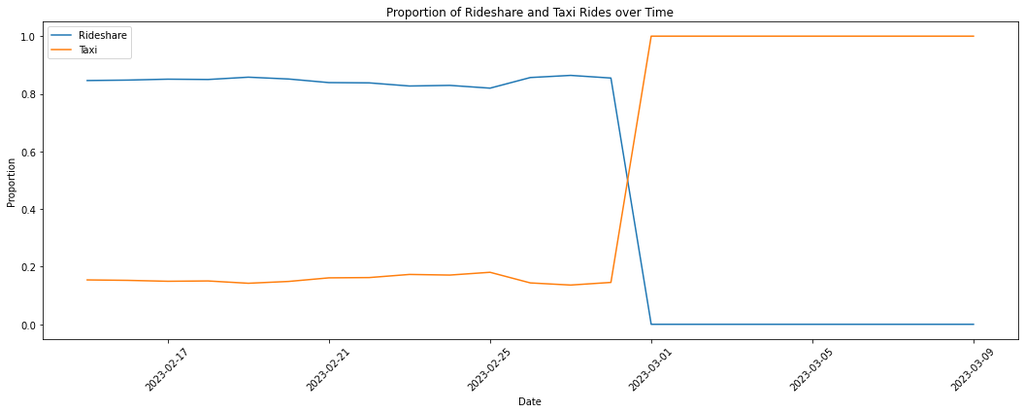

```python
# create a figure and axis object
fig, ax = plt.subplots(figsize=(18, 6))

# plot the proportion of rideshare and taxi rides over time
ax.plot(grouped.index, grouped['Proportion_rideshare'], label='Rideshare')
ax.plot(grouped.index, grouped['Proportion_taxi'], label='Taxi')

# set the x-axis label and rotate the x-tick labels for better readability
ax.set_xlabel('Date')
plt.xticks(rotation=45)

# set the y-axis label
ax.set_ylabel('Proportion')

# set the title of the plot
ax.set_title('Proportion of Rideshare and Taxi Rides over Time')

# add a legend to the plot
ax.legend()

# display the plot
plt.show()
```

The dataset contains ride-sharing and taxi rides, with the date and time of the pickup. We have converted the type of rides into two binary features.

To get some good ideas, we can preprocess the data using techniques such as data transformation, normalization, integration, and feature extraction.

- Data transformation involves converting the data from one format to another, such as converting text data to numeric data.
- Normalization scales the data to a range between 0 and 1 or -1 to 1 to ensure consistency and comparability.
- Integration involves combining data from multiple sources to form a single dataset.
- Feature extraction involves selecting or deriving relevant features from the dataset that are important for modelling and analysis.

Besides, Exploratory data analysis techniques such as visualization can be used to identify trends and patterns in the number of rides and distribution of pickup times for each type of ride. Classification modelling can help predict the ride type based on the pickup date and time, while clustering can be used to identify natural groupings and patterns in the data.

Overall, these techniques can provide valuable insights into the dataset and help us make informed decisions about how to analyze and interpret the data.